# Grappling with the “VISQ” subscales

Last updated 2018-04-08

Here we look at the VISQ subscales (McCarthy-Jones & Fernyhough; Packet 2) in detail.

# Differences across fieldsites

## Mean scores by site

First, let’s look at scores for participants in each site:

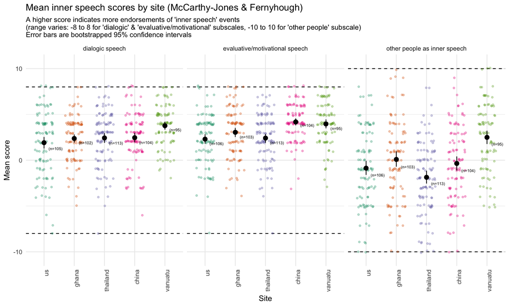

Note that this plot includes both average scores for each site (in black), and individual scores for all of the participants in that site (small, colorful points in the background, which are “jittered” around a little so that you can see them all).

I have not looked at this in detail.

Now let’s look at these differences in more detail using the “raw data” for individual questions, rather than these subscale scores.

## Responses by question, by site

```
Column `question` joining character vector and factor, coercing into character vectorIgnoring unknown aesthetics: fill
```

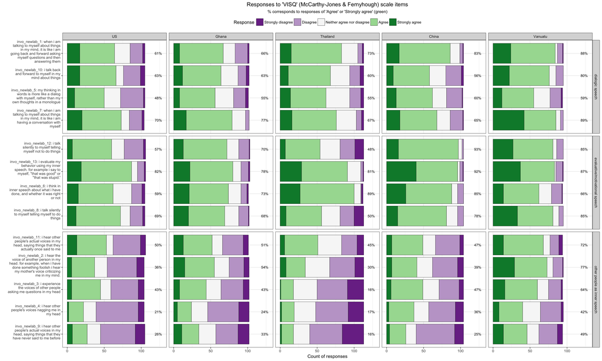

I have not yet looked at this in detail.

# Distribution of responses for individual participants, by site

Another thing we might be interested in is how individual participants responded: Were there people who said yes to everything, or no to everything? How do these distributions of responses differ across participants in different sites?

Let’s take a look:

```
Column `question` joining character vector and factor, coercing into character vector
```

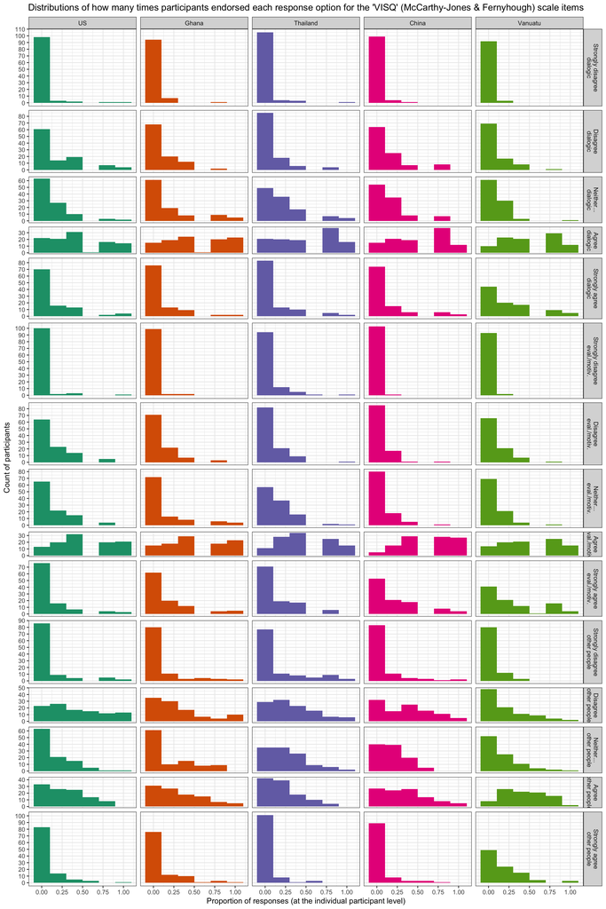

I have not yet looked at this in detail.

Just for fun, here’s another way to look at the same data, overlaying the density distributions for each site on top of each other to see where they seem to be similar/different:

```
Column `question` joining character vector and factor, coercing into character vector
```

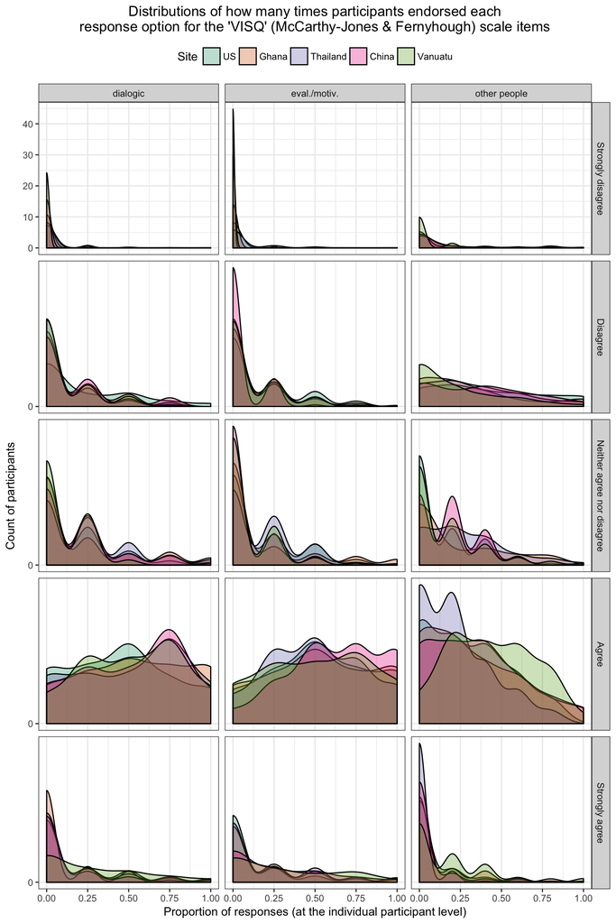